# A Computational Literature Review of Machine Intelligence in Education using Probalistic Topic Modeling

Jeanne McClure

March 24, 2022

# 1. PURPOSE

### 1a. Motivation and Focus

This research aims to illustrate the use of concepts, techniques, and mining process tools generate topics from a literature review looking at what the current state of AI or Machine Intelligence is in Education.

Methods for conducting semantic literature reviews are lengthy and require rigorous attention to reading and coding. In order to aquire a sense of what the most important topics are within the literature, the researcher needs to quickly assess an overview of what journals are most important with answering the research questions.

Coppin, is the ability of machines to adapt to new situations, deal with emerging situations, solve problems, answer questions, device plans, and perform various other functions that require some level of intelligence typically evident in human beings. Whitby defined artificial intelligence as the study of intelligence behavior in human beings, animals, and machines and endeavoring to engineer such behavior into an artifact, such as computers and computer-related technologies

**Guiding Questions:**

1. What is the current state of research of machine intelligence in educational contexts?
2. In what ways, if any, is machine intelligence supporting teaching and learning?
3. What Machine Intellience topics have emerged over time in teaching and learning?

### 1b. Load Libraries

First we load our libraries to read in packages that we will use to answer our questions. Focusing on Topic Modeling packages that will benefit our research. We will also set our parameters to assist with colors, theme and style.

```r
library(tidyverse)
library(data.table)
library(dendextend)
library(tidytext)
library(topicmodels)
library(tidyr)
library(dplyr)
library(ggplot2)
library(kableExtra)
library(knitr)
library(ggrepel)
library(gridExtra)
library(formattable)
library(tm)
library(circlize)
library(plotly)
library(wordcloud2)
library(lubridate)
library(stringr)
library(SnowballC)
if(!require("quanteda")) {install.packages("quanteda"); library("quanteda")}
if(!require("ldatuning")) {install.packages("ldatuning"); library("ldatuning")}

#SET PARAMETERS
#define colors to use throughout
my_colors <- c("#E69F00", "#56B4E9", "#009E73", "#CC79A7", "#D55E00", "#D65E00")

theme_plot <- function(aticks = element_blank(),
                         pgminor = element_blank(),
                         lt = element_blank(),
                         lp = "none")
{
  theme(plot.title = element_text(hjust = 0.5), #center the title
        axis.ticks = aticks, #set axis ticks to on or off
        panel.grid.minor = pgminor, #turn on or off the minor grid lines
        legend.title = lt, #turn on or off the legend title
        legend.position = lp) #turn on or off the legend
}

#customize the text tables for consistency using HTML formatting
my_kable_styling <- function(dat, caption) {
  kable(dat, "html", escape = FALSE, caption = caption) %>%
  kable_styling(bootstrap_options = c("striped", "condensed", "bordered"),
                full_width = FALSE)
}

word_chart <- function(data, input, title) {
  data %>%
  #set y = 1 to just plot one variable and use word as the label
  ggplot(aes(as.factor(row), 1, label = input, fill = factor(topic) )) +
  #you want the words, not the points
  geom_point(color = "transparent") +
  #make sure the labels don't overlap
  geom_label_repel(nudge_x = .2,
                   direction = "y",
                   box.padding = 0.1,
                   segment.color = "transparent",
                   size = 3) +
  facet_grid(~topic) +
  theme_plot() +
  theme(axis.text.y = element_blank(), axis.text.x = element_blank(),
        #axis.title.x = element_text(size = 9),
        panel.grid = element_blank(), panel.background = element_blank(),
        panel.border = element_rect("lightgray", fill = NA),
        strip.text.x = element_text(size = 9)) +
  labs(x = NULL, y = NULL, title = title) +
    #xlab(NULL) + ylab(NULL) +
  #ggtitle(title) +
  coord_flip()
}
```

# 2. METHOD

Our initial read-in data frame includes **137 observations** that include **eighteen variables**, including, Author, Title, Abstract and date. After reading in the data we will, wrangle the data. Data wrangling involves some combination of cleaning, reshaping, transforming, and merging data (Wickham & Grolemund, 2017). Then Cast a DTM and tokenize.

### 2a. Read and Inspect the Meta-Data

```r
#read in literature review
review_data3 <-read_csv("data/review_noCR1.csv")
```

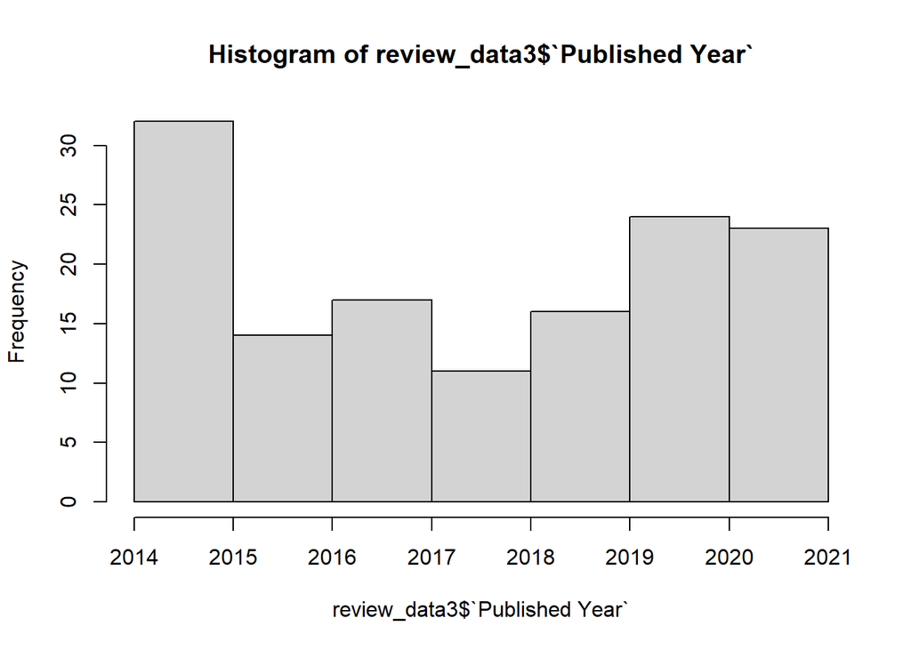

```r
hist(review_data3$`Published Year`)
```

### 2b. Tidy Data

Tidy data by converting to lowercase, and only select abstract, published_year, journal, field and subfield. add a unique identifier and unite document as “field.”

```r
# convert all variable names to lower case
names(review_data3) <- tolower(names(review_data3))

#Clean Data and include unique identifier
tidy_data3 <- review_data3 %>%
  rename(published_year = `published year`)%>%
  select(c('title', 'abstract', 'published_year', 'journal', 'field', 'subfield')) %>% # only select
  mutate(number = row_number())%>%
  unite(document, field)

# make number an as.facto
# inspect
tidy_data3%>%
  head(n=2)%>%
  kbl(caption = "First 2 - Tidy and Restructured Meta-Data") %>%
  kable_styling(bootstrap_options = c("striped", "hover"))
```

First 2 - Tidy and Restructured Meta-Data

| title | abstract | published_year | journal | document | subfield | number |
| --- | --- | --- | --- | --- | --- | --- |
| Crowd explicit sentiment analysis. | With the rapid growth of data generated by social web applications new paradigms in the generation of knowledge are opening. This paper introduces Crowd Explicit Sentiment Analysis (CESA) as an approa… | 2014 | Knowledge-Based Systems | ai | ai | 1 |
| Docode 5: Building a real-world plagiarism detection system. | Plagiarism refers to the appropriation of someone else’s ideas and expression. Its ubiquity makes it necessary to counter it, and invites the development of commercial systems to do so. In this docume… | 2017 | Engineering Applications of Artificial Intelligence | engineering | eng_ai | 2 |

Now, let’s inspect how many journal contributions by each journal exist. It looks as though the two journals with the highest paper contributions are ‘International Journal of Artificial Intelligence in Education’ (Springer Science & Business Media B.V.) and ‘Computers in Education.’

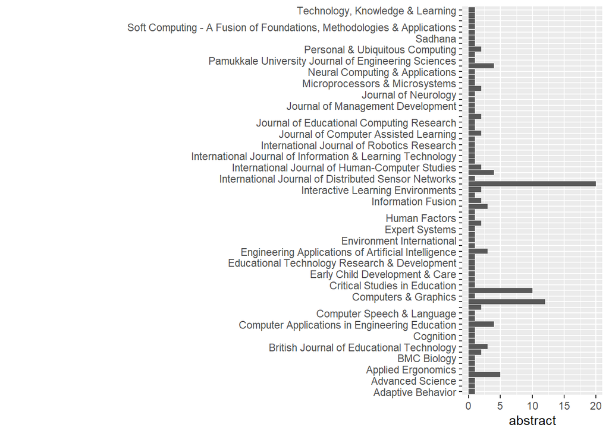

```r
library(ggplot2)

tidy_data3 %>%
  group_by(journal) %>%
  summarize(abstract = n_distinct(number)) %>%
  ggplot(aes(abstract, journal)) +
  geom_col() +
  scale_y_discrete(guide = guide_axis(check.overlap = TRUE)) +
  labs(y = NULL)
```

### 2c. Unnest tokenize

Here we will take the necessary steps to: 1. Transforming our text into “tokens” 2. Removing unnecessary characters, punctuation, and whitespace 3. Converting all text to lowercase 4. Removing stop words such as “the”, “of”, and “to”

After transforming we can quickly look at the word count. We can see that “learning” and “students” are at the top. This is exciting since we have papers from five different fields.

```r
#unnest
token_words3 <- tidy_data3 %>%
  unnest_tokens(word, abstract) %>%
  filter(str_detect(word, "[a-z']$"),
         !word %in% stop_words$word)


token_words3 %>%
  group_by(word) %>%
  filter(n() >= 98) %>%
  count(word, sort = TRUE)%>%
  kbl(caption = "Tokenized Words >= 98") %>%
  kable_styling(bootstrap_options = c("striped", "hover"))
```

Tokenized Words >= 98

| word | n |
| --- | --- |
| learning | 386 |
| students | 180 |
| system | 139 |
| based | 138 |
| design | 137 |
| user | 116 |
| data | 98 |

We can also look at the top words in a word cloud: This is a nice visualization to see the top tokenized words from the abstracts.

```r
top_tokens <- token_words3 %>%
  ungroup ()%>%  #ungroup the tokenize data to create a wordcloud
  count(word, sort = TRUE) %>%
  top_n(50)

wordcloud2(top_tokens)
```

[interactive chart not shown]

### 2d. Create Document Term Matrix and inspect

When organizing the MetaData we organized the journals into their respective fields. We will use the fields as the document to connet the topics later on. We have 5 documents and 3854 terms.

```r
review_dtm3 <- token_words3 %>%
  count(document, word, sort = TRUE) %>%
  ungroup()

cast_dtm3 <- review_dtm3 %>%
  cast_dtm(document, word, n)

dim(cast_dtm3)
```

```
## [1]    5 3854
```

```r
cast_dtm3
```

```
## <<DocumentTermMatrix (documents: 5, terms: 3854)>>
## Non-/sparse entries: 6253/13017
## Sparsity           : 68%
## Maximal term length: 22
## Weighting          : term frequency (tf)
```

We can inspect five documents looking at 8 words within the DTM.

```r
#look at 4 documents and 8 words of the DTM
inspect(cast_dtm3[1:5,1:8])
```

```
## <<DocumentTermMatrix (documents: 5, terms: 8)>>
## Non-/sparse entries: 39/1
## Sparsity           : 3%
## Maximal term length: 11
## Weighting          : term frequency (tf)
## Sample             :
##              Terms
## Docs          based data design intelligent learning results students system
##   ai              9    8     12           7       15       4       20     18
##   education      64   53     91          52      235      53      141     67
##   engineering    11   10      2           1       20       5        5     23
##   science         8    5      2           8       17       3        0      6
##   technology     46   22     30           8       99      20       14     25
```

Use generic variable names for the DTM = source_dtm3 and the tokenize words = source_tidy3.

```r
#assign the source dataset to generic var names

source_dtm3 <- cast_dtm3
source_tidy3 <- token_words3
```

### 2c. Look at DTM clusters

We will create a dendogram to see if we can identify clusters from the document term matrix. Although we see three distinct groups here and there are not very many titles is is hard to know exactly what the topics might be in rlation to our research questions.

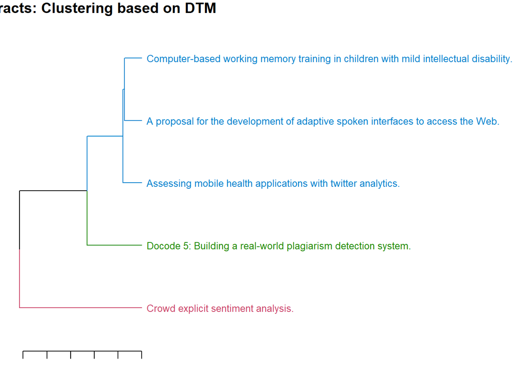

```r
dend<- source_dtm3 %>% dist() %>% hclust(method= "ward.D") %>%
       as.dendrogram() %>%
       set_labels(tidy_data3$title) %>%
       color_branches(h= 145) %>%
       color_labels(h= 145) %>%
       set("labels_cex", 0.8)

par(mar= c(1,1,1,25))
plot(dend, horiz= TRUE, main= "MI Abstracts: Clustering based on DTM")
```

# 3. MODEL

### 3a. Fit Topic Model

```r
k <- 5 #number of topics
seed = 1234 #necessary for reproducibility
#fit the model
#you could have more control parameters but will just use seed here
lda <- LDA(source_dtm3, k = k, method = "GIBBS", control = list(seed = seed))
#examine the class of the LDA object
class(lda)
```

```
## [1] "LDA_Gibbs"
## attr(,"package")
## [1] "topicmodels"
```

```r
#inspect lda topics
lda
```

```
## A LDA_Gibbs topic model with 5 topics.
```

# 4. EXPLORE

### 4a. Beta Values

Jiang (2022) notes that “hidden within our topic model object we created are per-topic-per-word probabilities, called β (”beta”).” It is the probability of a term (word) belonging to a topic. We will extract the per-topic-per-word probabilities, called β from the model and show top 5 results in each topic.

```r
topics <- tidy(lda, matrix = "beta")
topics%>%
  head %>%
  kbl(caption = "Term Probability by topic") %>%
  kable_styling(bootstrap_options = c("striped", "hover"))
```

Term Probability by topic

| topic | term | beta |
| --- | --- | --- |
| 1 | learning | 0.0000229 |
| 2 | learning | 0.0000416 |
| 3 | learning | 0.0000446 |
| 4 | learning | 0.0004108 |
| 5 | learning | 0.0535799 |
| 1 | students | 0.0370904 |

Now let’s look at the Top Beta Terms

```r
review_topics3 <- tidy(lda, matrix = "beta")

top_terms <- review_topics3 %>%
  group_by(topic) %>%
  slice_max(beta, n = 5) %>%

  ungroup() %>%
  arrange(topic, -beta)

top_terms%>%
  head %>%
  group_by(topic)%>%
  kbl(caption = "Top terms by Beta") %>%
  kable_styling(bootstrap_options = c("striped", "hover"))
```

Top terms by Beta

| topic | term | beta |
| --- | --- | --- |
| 1 | students | 0.0370904 |
| 1 | training | 0.0121499 |
| 1 | education | 0.0096330 |
| 1 | tutoring | 0.0094042 |
| 1 | student | 0.0094042 |
| 2 | user | 0.0125291 |

Here we are seeing there are few words that may need to be stemed or included in stop words - like student and students, and bold may be part of the html…i’ll have to look again…..

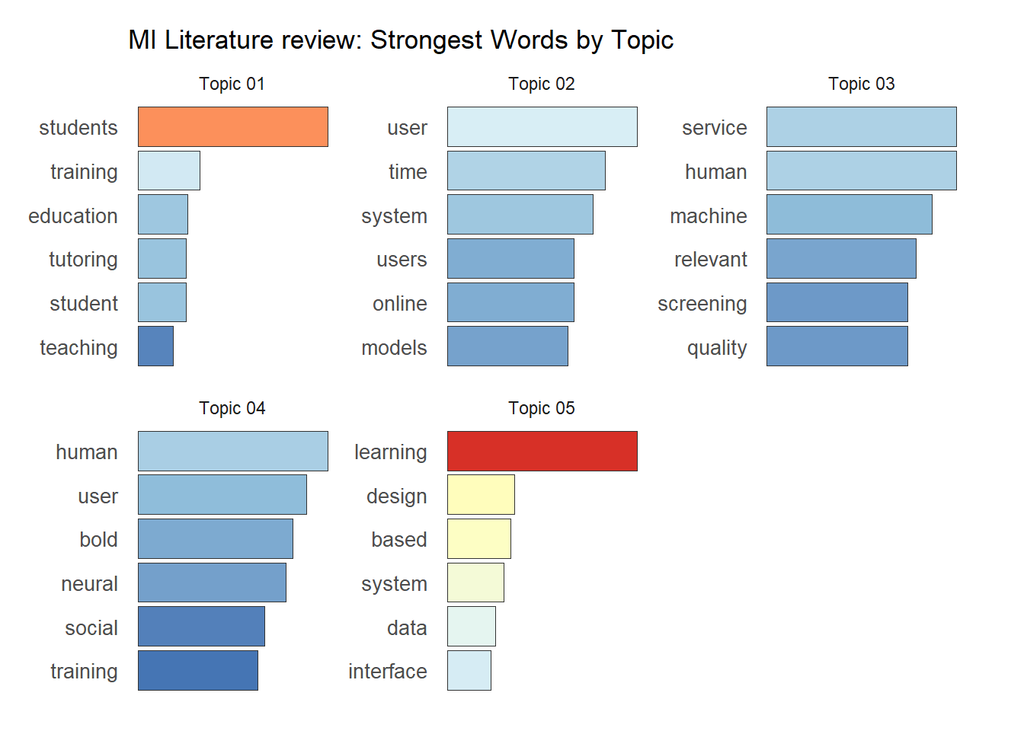

```r
# this is part set up for topics over time
topterms2 <- tidy(lda, matrix = "beta") %>%
  group_by(topic) %>%
  arrange(topic, desc(beta)) %>%
  slice(seq_len(6)) %>%
  arrange(topic, beta) %>%
  mutate(row = row_number()) %>%
  ungroup() %>%
  mutate(topic = paste("Topic", str_pad(topic,width= 2, pad="0"), sep = " "))

#plot topterms2
topterms2 %>%
  mutate(topic = factor(topic),
         term = reorder_within(term, beta, topic)) %>%
  ggplot(aes(term, beta, fill = log(beta))) +
  geom_bar(stat = "identity", show.legend = FALSE, color= "grey20", size= 0.2) +
  scale_x_reordered() +
  facet_wrap(~ topic, scales = "free", ncol = 3) +
  coord_flip() +
  theme_minimal() +
  scale_fill_distiller(palette = "RdYlBu") +
  theme(legend.position = 'none',
        panel.grid = element_blank(),
        axis.text.y = element_text(size= 10),
        axis.text.x = element_blank(),
        plot.margin = margin(0.5, 1, 0.5, 0.5, "cm")) +
  labs(title= "MI Literature review: Strongest Words by Topic", y= NULL, x= NULL)
```

Finally, inspecting the terms in a nice layout for comparison of what is in each topic. We inspect 10 terms that are most common within each topic.

```r
num_words <- 10 #number of words to visualize

#create function that accepts the lda model and num word to display
top_terms_per_topic <- function(lda_model, num_words) {

  #tidy LDA object to get word, topic, and probability (beta)
topics_tidy <- tidy(lda_model, matrix = "beta")

  top_terms <- topics_tidy %>%
  group_by(topic) %>%
  arrange(topic, desc(beta)) %>%
  #get the top num_words PER topic
  slice(seq_len(num_words)) %>%
  arrange(topic, beta) %>%
  #row is required for the word_chart() function
  mutate(row = row_number()) %>%
  ungroup() %>%
  #add the word Topic to the topic labels
  mutate(topic = paste("Topic", topic, sep = " "))
  #create a title to pass to word_chart
  title <- paste("LDA Top Terms for", k, "Topics")
  #call the word_chart function
  word_chart(top_terms, top_terms$term, title)
}
```

#REVIST THIS ONE… I am not sure I am going to use this. I wanted a stacked bar graph with the topics by year. I went to the Data visualization and this is what he showed me. It has potential but I am not sure it is the time I’m looking for.

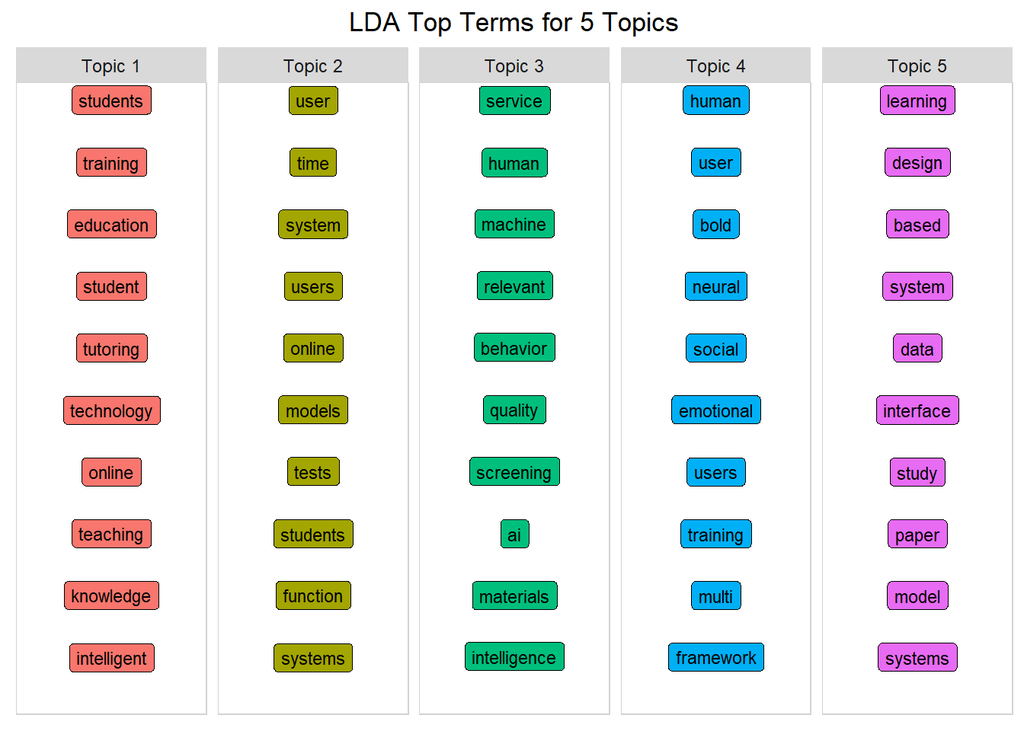

```r
top_terms_per_topic(lda, num_words)
```

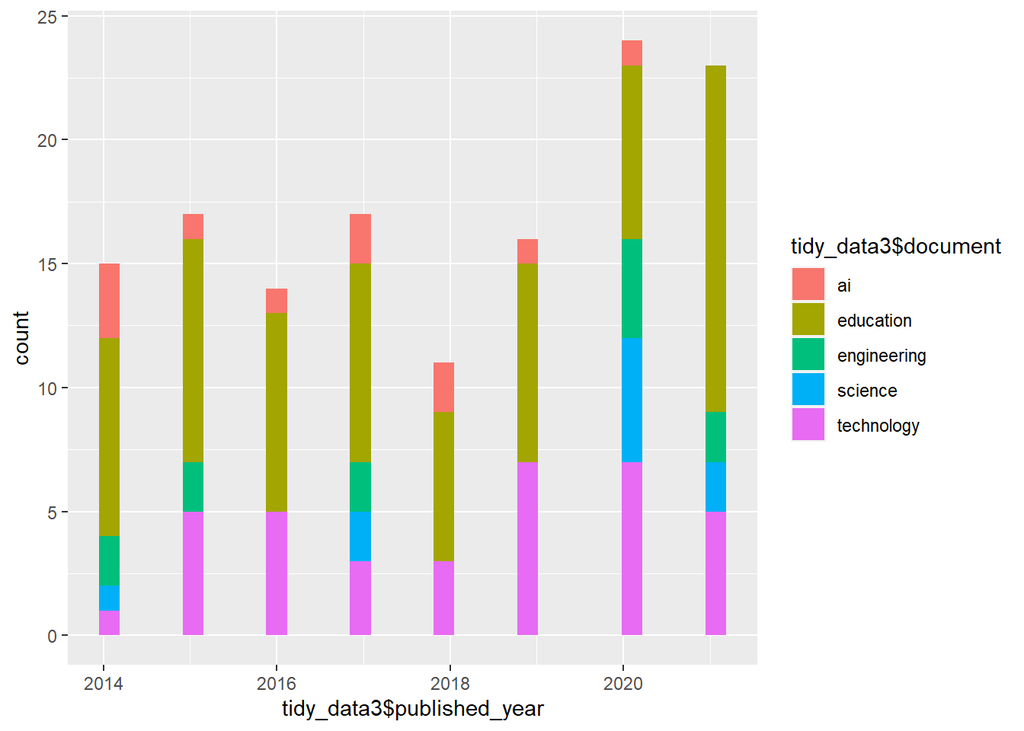

```r
library(ggplot2)
ggplot(data = tidy_data3, aes(x=tidy_data3$published_year, fill = tidy_data3$document)) +geom_histogram()
```

### 4b. Gamma

Silge & Robinson (2017) state, “besides estimating each topic as a mixture of words, LDA also models each document as a mixture of topics. We can examine the per-document-per-topic probabilities, called γ(“gamma”), with the matrix = “gamma” argument to tidy().

Show relationship between topic and journal document field.

```r
tidy_data3
```

```
## # A tibble: 137 x 7
##    title                abstract published_year journal document subfield number
##    <chr>                <chr>             <dbl> <chr>   <chr>    <chr>     <int>
##  1 "Crowd explicit sen~ "With t~           2014 Knowle~ ai       ai            1
##  2 "Docode 5: Building~ "Plagia~           2017 Engine~ enginee~ eng_ai        2
##  3 "Assessing mobile h~ "<bold>~           2018 Intern~ technol~ tech_he~      3
##  4 "A proposal for the~ "Spoken~           2015 Neuroc~ technol~ tech_nc       4
##  5 "Computer-based wor~ "We des~           2015 Early ~ educati~ edu_ear~      5
##  6 "Sequential deep le~ "• Sequ~           2021 Safety~ enginee~ eng_saf~      6
##  7 "How Does Prior Kno~ "The go~           2019 Intern~ educati~ edu_ai        7
##  8 "Toward \"On-Demand~ "A Mate~           2020 Advanc~ science  sci_mul~      8
##  9 "SWIFT-Active Scree~ "• Mach~           2020 Enviro~ science  sci_env~      9
## 10 "Elicitation of lat~ "Highli~           2014 Comput~ technol~ tech_hu~     10
## # ... with 127 more rows
```

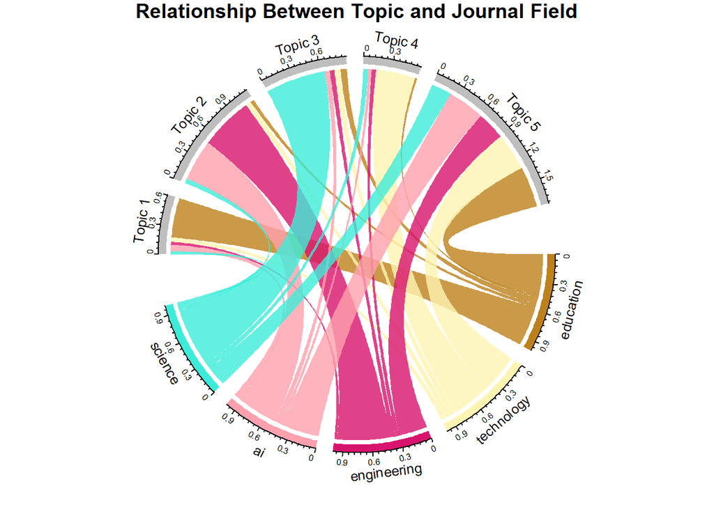

```r
#using tidy with gamma gets document probabilities into topic
#but only have document, topic and gamma
source_topic_relationship <- tidy(lda, matrix = "gamma") %>%
  #join to orig tidy data bydoc to get the source field
  inner_join(tidy_data3, by = "document") %>%
  select(document, topic, gamma) %>%
  group_by(document, topic) %>%
  #get the avg doc gamma value per source/topic
  mutate(mean = mean(gamma)) %>%
  #remove the gamma value as you only need the mean
  select(-gamma) %>%
  #removing gamma created duplicates so remove them
  distinct()

#relabel topics to include the word Topic
source_topic_relationship$topic = paste("Topic", source_topic_relationship$topic, sep = " ")

circos.clear() #very important! Reset the circular layout parameters
#assign colors to the outside bars around the circle
grid.col = c("Education" = my_colors[1],
             "Science" = my_colors[2],
             "AI" = my_colors[3],
             "Technology" = my_colors[4],
             "Engineering"= my_colors[5],
             "Topic 1" = "grey", "Topic 2" = "grey", "Topic 3" = "grey", "Topic 4" = "grey", "Topic 5" = "grey")

# set the global parameters for the circular layout. Specifically the gap size (15)
#this also determines that topic goes on top half and source on bottom half
circos.par(gap.after = c(rep(5, length(unique(source_topic_relationship[[1]])) - 1), 15,
                         rep(5, length(unique(source_topic_relationship[[2]])) - 1), 15))
#main function that draws the diagram. transparancy goes from 0-1
chordDiagram(source_topic_relationship, grid.col = grid.col, transparency = .2)
title("Relationship Between Topic and Journal Field")
```

### 4c Combine Gamma and Beta

```r
#save to beta var
td_beta <- tidy(lda)
#save to gamma var
td_gamma <- tidy(lda, matrix = "gamma")
#copy Julia Silge code to combine
top_terms <- td_beta %>%
  arrange(beta) %>%
  group_by(topic) %>%
  top_n(7, beta) %>%
  arrange(-beta) %>%
  select(topic, term) %>%
  summarise(terms = list(term)) %>%
  mutate(terms = map(terms, paste, collapse = ", ")) %>%
  unnest()

gamma_terms <- td_gamma %>%
  group_by(topic) %>%
  summarise(gamma = mean(gamma)) %>%
  arrange(desc(gamma)) %>%
  left_join(top_terms, by = "topic") %>%
  mutate(topic = paste0("Topic ", topic),
         topic = reorder(topic, gamma))

gamma_terms %>%
  select(topic, gamma, terms) %>%
  kable(digits = 3,
        col.names = c("Topic", "Expected topic proportion", "Top 7 terms"))
```

| Topic | Expected topic proportion | Top 7 terms |
| --- | --- | --- |
| Topic 5 | 0.352 | learning, design, based, system, data, interface, study |
| Topic 2 | 0.232 | user, time, system, online, users, models, tests |
| Topic 3 | 0.177 | human, service, machine, relevant, screening, quality, behavior |
| Topic 1 | 0.122 | students, training, education, tutoring, student, teaching, online, technology |
| Topic 4 | 0.117 | human, user, bold, neural, social, training, users, emotional |

Let’s assign the top terms to a label. We wil use this later on but it helps us know the key words that are influential in each topic.

```r
topicLabels<- topterms2 %>%
  ungroup() %>%
  arrange(topic, desc(beta)) %>%
  group_by(topic)%>%
  mutate(Order= order(desc(beta))) %>%
  filter(Order < 5) %>%
  summarise(Label= str_c(term, collapse=" ")) %>%
  mutate(topic= str_sub(topic, 7),
         Label= paste0(topic,": ", str_to_sentence(Label)),
         topic= as.numeric(topic)) %>%
  print()
```

```
## # A tibble: 5 x 2
##   topic Label
##   <dbl> <chr>
## 1     1 01: Students training education tutoring
## 2     2 02: User time system online
## 3     3 03: Human service machine relevant
## 4     4 04: Human user bold neural
## 5     5 05: Learning design based system
```

### 4d. Fit Model 2 K-Means

The structure of the k-means object reveals two important pieces of information: clusters and centers. k-means clustering, each document—can be assigned to one, and only one, cluster. To get a more stable K means we will set ‘nstart’ to 25. This will try 25 different random starting assignments and then select the best results corresponding to the one with the lowest within cluster variation.

```r
source_dtm2 <- cast_dtm3
source_tidy2 <- token_words3
#Set a seed for replicable results
set.seed(1234)
k <- 4
kmeansResult <- kmeans(source_dtm2, k, nstart = 25)
str(kmeansResult)
```

```
## List of 9
##  $ cluster     : Named int [1:5] 3 4 1 1 2
##   ..- attr(*, "names")= chr [1:5] "education" "technology" "engineering" "ai" ...
##  $ centers     : num [1:4, 1:3854] 17.5 17 235 99 12.5 0 141 14 7 2 ...
##   ..- attr(*, "dimnames")=List of 2
##   .. ..$ : chr [1:4] "1" "2" "3" "4"
##   .. ..$ : chr [1:3854] "learning" "students" "design" "system" ...
##  $ totss       : num 133221
##  $ withinss    : num [1:4] 2626 0 0 0
##  $ tot.withinss: num 2626
##  $ betweenss   : num 130595
##  $ size        : int [1:4] 2 1 1 1
##  $ iter        : int 2
##  $ ifault      : int 0
##  - attr(*, "class")= chr "kmeans"
```

Let’s visualize what is going on her. Looks like we have 4 clusters with education in cluster 3, technology in cluster 4, engineering, ai in cluster 1 and science in cluster 2. The size is not very large at all.

```r
kmeansResult$cluster
```

```
##   education  technology engineering          ai     science
##           3           4           1           1           2
```

```r
#cluster size
kmeansResult$size
```

```
## [1] 2 1 1 1
```

Intelligence is in all four clusters, but falls mainly in cluster three.

```r
head(kmeansResult$centers[,"intelligent"])
```

```
##  1  2  3  4
##  4  8 52  8
```

Let’s take a look at “ai” and see how many times it appears in the topics.

```r
head(kmeansResult$centers[,"ai"])
```

```
##  1  2  3  4
##  0 10 25 14
```

It also seems to appear the most in Topic 3.

#### K Means top terms

```r
num_words <- 8 #number of words to display
#get the top words from the kmeans centers
kmeans_topics <- lapply(1:k, function(i) {
  s <- sort(kmeansResult$centers[i, ], decreasing = T)
  names(s)[1:num_words]
})

#make sure it's a data frame
kmeans_topics_df <- as.data.frame(kmeans_topics)
#label the topics with the word Topic
names(kmeans_topics_df) <- paste("Topic", seq(1:k), sep = " ")
#create a sequential row id to use with gather()
kmeans_topics_df <- cbind(id = rownames(kmeans_topics_df),
                          kmeans_topics_df)
kmeans_topics_df
```

```
##   id  Topic 1      Topic 2     Topic 3   Topic 4
## 1  1   system     learning    learning  learning
## 2  2 learning        human    students     based
## 3  3     user      service      design      user
## 4  4 students    screening      system     model
## 5  5  systems           ai       based     human
## 6  6    based intelligence        data    design
## 7  7     data      machine     results     paper
## 8  8    users   artificial intelligent interface
```

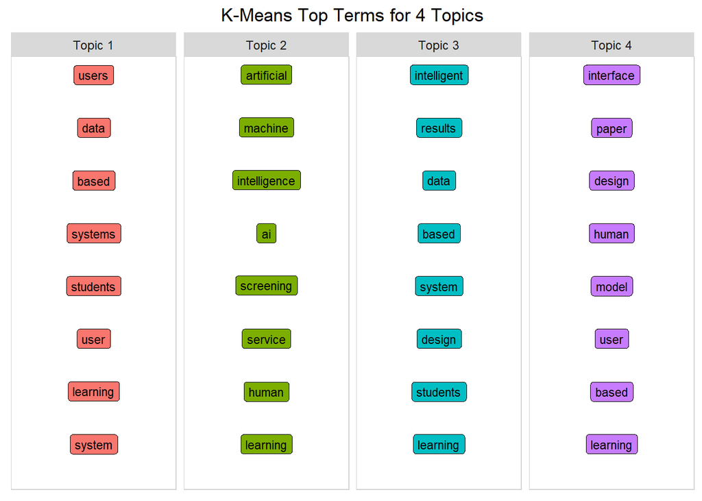

```r
#transpose it into the format required for word_chart()
kmeans_top_terms <- kmeans_topics_df %>%
  gather(id)
  colnames(kmeans_top_terms) = c("topic", "term")

kmeans_top_terms <- kmeans_top_terms %>%
  group_by(topic) %>%
  mutate(row = row_number()) %>% #needed by word_chart()
  ungroup()

title <- paste("K-Means Top Terms for", k, "Topics")
word_chart(kmeans_top_terms, kmeans_top_terms$term, title)
```

#### 2 dimensional space tSNE let’s see what top clustering terms look like in two dimensional space.

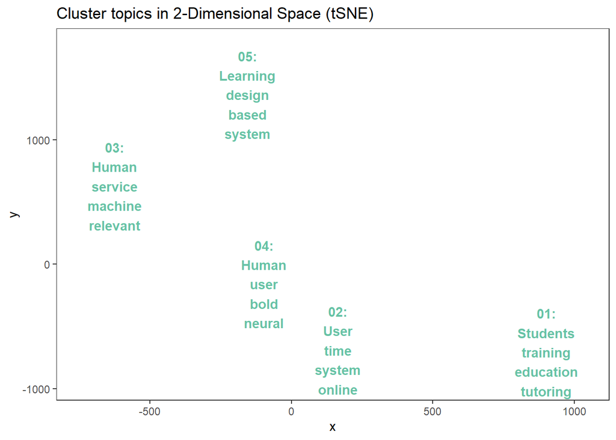

```r
mytSNE<- function(thematrix){
  perplex<- round(sqrt(nrow(thematrix)))
  res<- Rtsne::Rtsne(thematrix, dims= 2, perplexity= 1)
  resdf<- data.frame(x= res$Y[,1], y= res$Y[,2])
  resdf$x<- resdf$x + rnorm(nrow(resdf),0, 0.2)  # Add some noise
  resdf$y<- resdf$y + rnorm(nrow(resdf),0, 0.2)
  return(resdf)
}

bt<-      lda %>% tidy(matrix= "beta") %>% spread(term, beta)
hc<-      bt %>% dist() %>% hclust(method= "ward.D")
library(dendextend)
library(Rtsne)
tsne<-    mytSNE(bt) %>%
  mutate(text=str_wrap(topicLabels$Label,5), color= cutree(hc, h=0.12))

library(RColorBrewer)
ggplot(tsne, aes(x= x, y=y, color= factor(color))) +
  geom_text_repel(aes(label= text), segment.alpha= 0, fontface= "bold")  +
  theme_bw() +
  theme(legend.position = "none",
        panel.grid = element_blank()
        ) +
  scale_color_manual(values= brewer.pal(8,"Set2")) +
  labs(title= "Cluster topics in 2-Dimensional Space (tSNE)")
```

### 4e Topics over time

# MI abstracts by Highest Topic Gamma

An alternative method for grouping talks together would be to assign each talk to the topic with which they had the highest gamma score. This means some overlapping information is lost, but helps us sort the talks into categories.

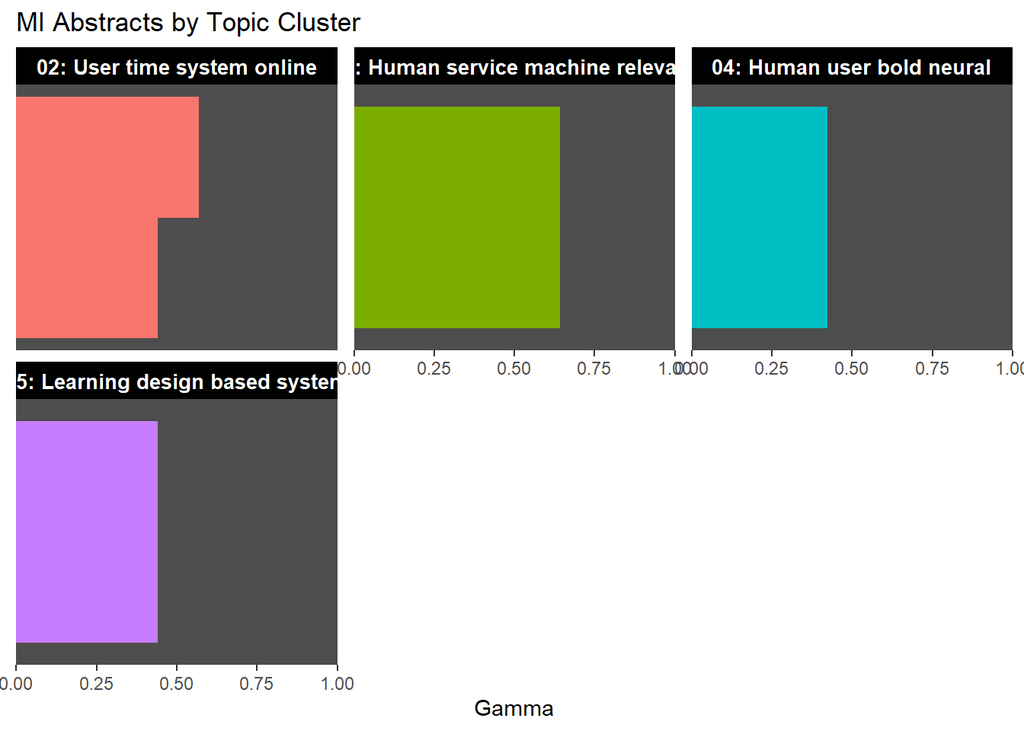

```r
titleRef<- tidy_data3 %>% select(document = number, title, published_year) %>% mutate(document= as.character(document))

dt0<- lda %>% tidy("gamma")
dt2<- dt0 %>% arrange(document, desc(gamma)) %>% group_by(document) %>% slice(1)
dt2<- dt2 %>% left_join(titleRef) %>% left_join(topicLabels)

dt2<- dt2 %>% ungroup() %>% group_by(topic) %>% mutate(Order= order(gamma))

ggplot(dt2, aes(x= gamma, y= factor(Order), group= Label, fill= Label)) +
  geom_col(width=1) +
  geom_text(aes(x= 0.01, y= Order, label= title), hjust= 0, size= 3, fontface= "bold", color= "white") +
  scale_x_continuous(limits = c(0, 1), expand = c(0, 0)) +
  facet_wrap(~Label, scales= "free_y", ncol= 3) +
  theme(legend.position= "none",
        panel.background = element_rect(fill= "grey30"),
        panel.grid = element_blank(),
        strip.background = element_rect(fill= "black"),
        strip.text = element_text(face= "bold", color= "white", size= 10),
        axis.text.y =  element_blank(),
        axis.ticks.y = element_blank()) +
  labs(title= "MI Abstracts by Topic Cluster", x= "Gamma", y=NULL)
```

[figure not shown]

[figure not shown]

[figure not shown]

[figure not shown]

[figure not shown]

```r
byYear<- dt0 %>% left_join(titleRef) %>% left_join(topicLabels) %>%
  filter(published_year!= 2021) %>% group_by(published_year,topic, Label) %>% summarise(Sum_gamma= sum(gamma))
yearTotals<- byYear %>% group_by(published_year) %>% summarise(total_gamma= sum(Sum_gamma))

trendRef<- data.frame(
  stringsAsFactors = FALSE,
                        topic = c(4L,5L, 2L,1L,3L),
                        trend = c("Decreasing","Increasing Worm", "Lump", "Rocky","Worm"))

byYear<- left_join(byYear, yearTotals) %>% mutate(pc= Sum_gamma/total_gamma) %>% left_join(trendRef)
thetrends<- names(table(trendRef$trend))
for (k in 1:length(thetrends)) {
  sett<- byYear %>% filter(trend==thetrends[k])

g<- ggplot(sett, aes(x= published_year, y=pc, fill= Label)) +
  geom_area(aes(group= Label), position= "stack", color= "grey20", size= 0.3, show.legend = TRUE, alpha= 0.7) +
  labs(title= paste("Trend over time:",thetrends[k]), fill= "Topic", y= "Percent of Gamma by Year") +
  theme_bw() +
  ylim(0, 0.7) +
  scale_x_continuous(breaks= unique(byYear$published_year)) +
  theme(axis.text.x = element_text(angle= 90))
print(g)
}
```

# 5 Communication

## References:

Coppin, B. (2004). Artificial intelligence illuminated. Jones & Bartlett Learning.

Data Novia. (2022). K-Means Clustering in R: Algorithm and Practical Examples https://www.datanovia.com/en/lessons/k-means-clustering-in-r-algorith-and-practical-examples/

Simonite, T. (2014). 2014 in Computing: Breakthroughs in Artificial Intelligence.

Warwick, K. (2013). Artificial intelligence: the basics. Routledge.

Whitby, B. (2009). Artificial intelligence. The Rosen Publishing Group, Inc.